```python
import numpy as np
import pandas as pd
import matplotlib.pyplot as plt
import scipy
from scipy import stats
from collections import Counter
#this sets the size of the plot to something useful
plt.rcParams["figure.figsize"] = (20,15)
```

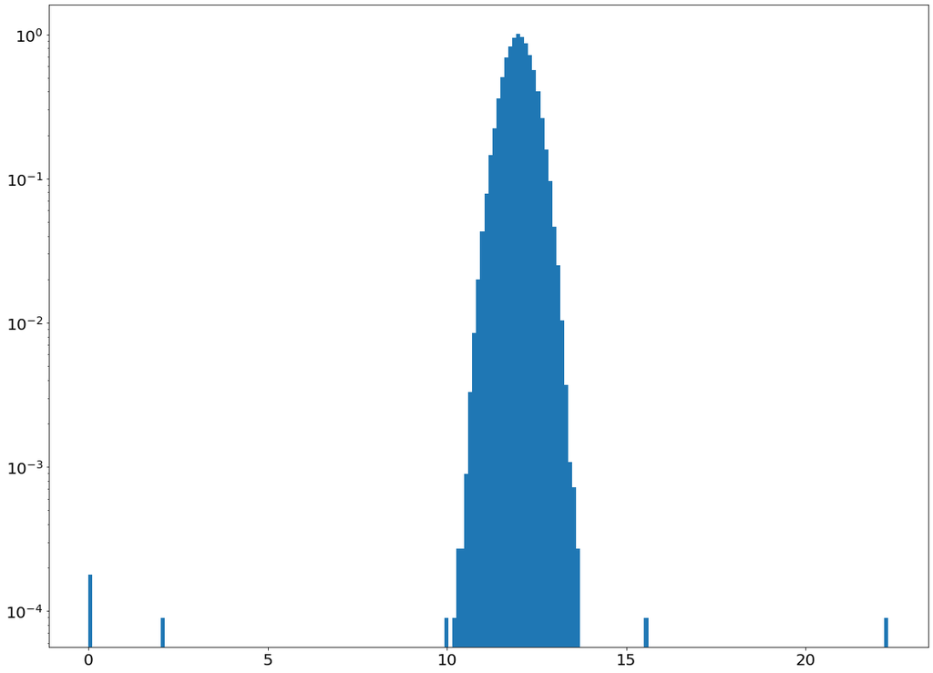

```python
noise = [10., 10.3, 2.1, 0., 0., 15.6, 22.3, 12.7]
pure = stats.norm.rvs(loc=12, scale=0.4, size=100000)
data = np.append(pure, noise)

plt.tick_params(labelsize = 20)

plt.hist(data, 200, density=True)
plt.yscale('log')
plt.show()
```

For the data above, we have a good data of Gaussian distribution. Also, we have some bad data adding to it. In a signifiance level of 5σ. (which is a common X*σ in physics), I want to see which part of my data is within that significance interval. Or we can say which part of the "bad data" is in the part of significance level. The question: Which part of the temperature above is within the range of 5σ? This question can be expressed in many ways to express the same idea. Two-tailed probability of 5σ， CDF within the range... \ the absolute value of $$\int_∞^a f(a)da$$ $\geq$ 5*σ

```python
X = np.sort(data)
clear = np.array([])
throw = np.array([])

def truthtable(sigma):
    sig = stats.norm.sf(sigma)
    max_t = stats.norm.isf(sig, loc=12, scale=0.4)
    min_t = stats.norm.isf(1-sig, loc=12, scale=0.4)

    count1 = 0
    count2 = 0
    for x in data:
        if(x > min_t and x < max_t): count1 = count1 + 1
        elif(x < min_t or x > max_t): count2= count2 + 1

    print("thrown values' # :",count2)
    print("# of elements after cleared:", count1)

    clear = X[np.logical_and(X > min_t, X < max_t)]
    throw = X[np.logical_or(X < min_t, X > max_t)]
    true_pos = sum((Counter(pure) & Counter(clear)).values())
    false_pos = sum((Counter(clear) & Counter(noise)).values())
    true_neg = sum((Counter(pure) & Counter(throw)).values())
    false_neg = sum((Counter(throw) & Counter(noise)).values())

    table = pd.DataFrame(data=[[true_pos,false_pos],[true_neg,false_neg]],
                     index=["Positive", "Negative"],
                     columns=["True", "False"])
    return table
```

```python
truthtable(5)
```

```
thrown values' # : 6
# of elements after cleared: 100002
```

|  | True | False |
| --- | --- | --- |
| Positive | 100000 | 2 |
| Negative | 0 | 6 |

False negative is regarded as type I error in statistic, which is more serious. So we want to find the value of x*σ, so that we can eliminate(or make it as small as possible) the type I error.

try a sigma value of 2.

```python
truthtable(2)
```

```
thrown values' # : 4674
# of elements after cleared: 95334
```

|  | True | False |
| --- | --- | --- |
| Positive | 95333 | 1 |
| Negative | 4667 | 7 |

Not so good.

```python
truthtable(8)
```

```
thrown values' # : 5
# of elements after cleared: 100003
```

|  | True | False |
| --- | --- | --- |
| Positive | 100000 | 3 |
| Negative | 0 | 5 |

Not so good.

We can see that when we change the sigma value. The number of both type I and type II error are changing. So it is a reasonable to complete eliminate at least one of them. I choose to elimnate type I error (since it is more serious). \ In math, find the value of x in x*σ, such that minimize the type I error.

```python
sigma = stats.norm.isf(stats.norm.sf(12.7, scale=0.4, loc=12))
print(f"Sigma value at 12.7: {sigma:.3f}")
```

```
Sigma value at 12.7: 1.750
```

plug in 1.75 to see if it works

```python
truthtable(1.75)
```

```
thrown values' # : 8117
# of elements after cleared: 91890
```

|  | True | False |
| --- | --- | --- |
| Positive | 91890 | 0 |
| Negative | 8110 | 7 |

# Problem 2

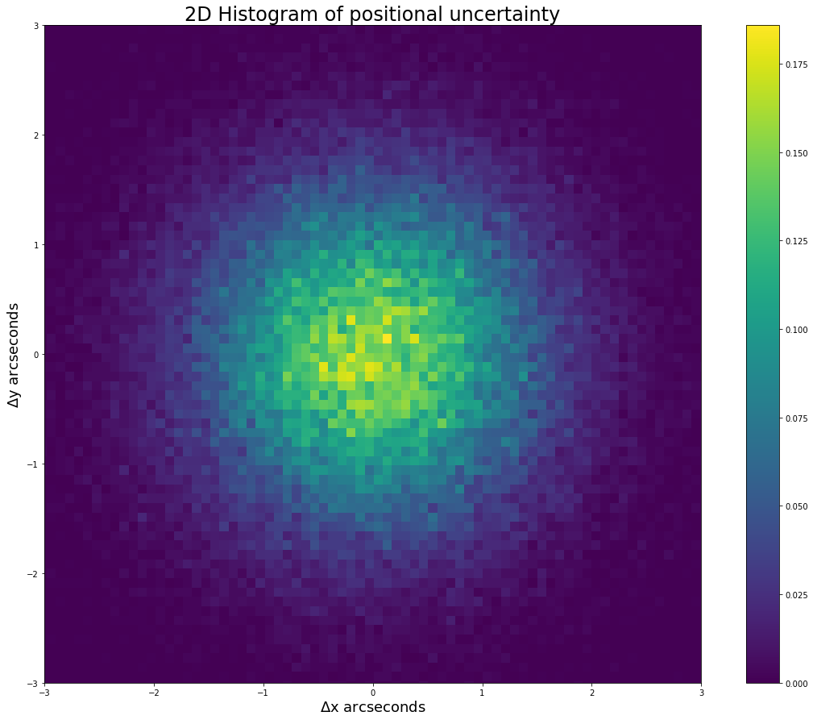

```python
a = np.vstack((stats.norm.rvs( scale = 1, size = 100000), stats.norm.rvs( scale = 1, size = 100000)))
a.shape
fig, ax = plt.subplots(1, 1)
h = ax.hist2d(a[0,:],a[1,:],bins=100, density=True);
ax.set_aspect('equal', 'box')
plt.xlim([-3 , 3])
plt.ylim([-3 , 3])
plt.title("2D Histogram of positional uncertainty", fontsize = 24)
plt.ylabel("$\Delta$y arcseconds", fontsize = 18)
plt.xlabel("$\Delta$x arcseconds", fontsize = 18)
plt.colorbar(h[3], ax=ax)
```

The graph we have is a 2_D gaussian distribution, with mean value at (0,0). The scale (or we can say standard deviation of this 2D Gaussian distribution) is 1 in the unit of arcseconds. So the question here. In words, what is the distance of a "possible asteroid" will be considered as a real asterioud? In math, for what distance, the asteroid have to travel in arcseconds, to have a confidence interval of 5σ(or a probability of 5σ), that it is a real asteroid( instead of some noise careated by the background).

Here to calculate the distance it moves, in arcseconds. we use the formula $\sqrt{\Delta x^2 + \Delta y^2 }$. Also, both x and y are normally distributed. From homework, we know that the new distribution of two squared normal distribution is a Rayleigh distribution(Rayl dist). Also from wikepedia(https://en.wikipedia.org/wiki/Rayleigh_distribution), we know that the parameters of the Rayl dist should be $\sqrt{\pi * 0.5}$, and the varience is $\sqrt{(4 - \pi)*0.5}$ \ so the equation is: 5*σ $\geq$ the absolute value of $$\int_∞^a f(a)da$$ \ solve for a

In math, solve the Percent Point Function of Rayleigh dist at 1 - 5 * σ

```python
sigma_5 = stats.norm.sf(5)
print("distance moved in one arcseconds should be : ",stats.rayleigh.ppf(1- sigma_5))
```

```
distance moved in one arcseconds should be :  5.489079776034238
```

# Problem 3

We are working on observing something over a time interval. This is the pattern of a Poisson distribution. So we set up the Poisson distribution. 1 ray per minute, 8 hours a night, 15 days. As a result, the parameter of Poisson distribution should be 60 *8* 15 = 7200 Notice that For sufficiently large values of λ, (say λ>1000), the normal distribution with mean λ and variance λ (standard deviation is an excellent approximation to the Poisson distribution. If λ is greater than about 10, then the normal distribution is a good approximation if an appropriate continuity correction is performed, i.e., if P(X ≤ x), where x is a non-negative integer, is replaced by P(X ≤ x + 0.5). Source:https://en.wikipedia.org/wiki/Poisson_distribution \ Then the question turns into, for a non-standard normal distribution with mean = 7200. We have a lower bound of 6800. Find the significance, in other words, find the x of x*σ, such that the signal can be considered as more signal like. \ Express in math: integrate the PDF from our Poisson distribution from 0 to 6800 with parameter 7200, and then convert it to a sigma value

```python
pois = stats.poisson(7200)
stats.norm.ppf(pois.cdf(6800))
```

```
-4.750747965777188
```

significance of our detection: $4.750747965777188\sigma$.